# Risk Factor Analysis

## Outcome Variable

**Outcome Variable:** stunted

## Predictor Variables

**Intervention Variable:** impsan

**Adjustment Set:**

- arm
- sex
- W_mage
- meducyrs
- feducyrs
- hhwealth_quart
- hfoodsec
- W_mhtcm
- W_mwtkg
- W_mbmi
- W_nrooms
- W_nchldlt5
- W_parity
- impfloor
- safeh20
- delta_W_mage
- delta_meducyrs
- delta_feducyrs
- delta_hhwealth_quart
- delta_hfoodsec
- delta_W_mhtcm
- delta_W_mwtkg
- delta_W_mbmi
- delta_W_nrooms
- delta_W_nchldlt5
- delta_W_parity
- delta_impfloor
- delta_safeh20

## Stratifying Variables

The analysis was stratified on these variable(s):

- agecat
- studyid
- country

## Data Summary

| agecat | studyid | country | impsan | stunted | n_cell | n |
| --- | --- | --- | --- | --- | --- | --- |
| Birth | ki0047075b-MAL-ED | BANGLADESH | 1 | 0 | 147 | 213 |
| Birth | ki0047075b-MAL-ED | BANGLADESH | 1 | 1 | 32 | 213 |
| Birth | ki0047075b-MAL-ED | BANGLADESH | 0 | 0 | 29 | 213 |
| Birth | ki0047075b-MAL-ED | BANGLADESH | 0 | 1 | 5 | 213 |
| Birth | ki0047075b-MAL-ED | BRAZIL | 1 | 0 | 50 | 60 |
| Birth | ki0047075b-MAL-ED | BRAZIL | 1 | 1 | 9 | 60 |
| Birth | ki0047075b-MAL-ED | BRAZIL | 0 | 0 | 1 | 60 |
| Birth | ki0047075b-MAL-ED | BRAZIL | 0 | 1 | 0 | 60 |
| Birth | ki0047075b-MAL-ED | INDIA | 1 | 0 | 13 | 40 |
| Birth | ki0047075b-MAL-ED | INDIA | 1 | 1 | 2 | 40 |
| Birth | ki0047075b-MAL-ED | INDIA | 0 | 0 | 20 | 40 |
| Birth | ki0047075b-MAL-ED | INDIA | 0 | 1 | 5 | 40 |
| Birth | ki0047075b-MAL-ED | NEPAL | 1 | 0 | 23 | 26 |
| Birth | ki0047075b-MAL-ED | NEPAL | 1 | 1 | 2 | 26 |
| Birth | ki0047075b-MAL-ED | NEPAL | 0 | 0 | 1 | 26 |
| Birth | ki0047075b-MAL-ED | NEPAL | 0 | 1 | 0 | 26 |
| Birth | ki0047075b-MAL-ED | PERU | 1 | 0 | 44 | 208 |
| Birth | ki0047075b-MAL-ED | PERU | 1 | 1 | 8 | 208 |
| Birth | ki0047075b-MAL-ED | PERU | 0 | 0 | 140 | 208 |
| Birth | ki0047075b-MAL-ED | PERU | 0 | 1 | 16 | 208 |
| Birth | ki0047075b-MAL-ED | SOUTH AFRICA | 1 | 0 | 0 | 95 |
| Birth | ki0047075b-MAL-ED | SOUTH AFRICA | 1 | 1 | 0 | 95 |
| Birth | ki0047075b-MAL-ED | SOUTH AFRICA | 0 | 0 | 87 | 95 |
| Birth | ki0047075b-MAL-ED | SOUTH AFRICA | 0 | 1 | 8 | 95 |
| Birth | ki0047075b-MAL-ED | TANZANIA, UNITED REPUBLIC OF | 1 | 0 | 0 | 118 |
| Birth | ki0047075b-MAL-ED | TANZANIA, UNITED REPUBLIC OF | 1 | 1 | 0 | 118 |
| Birth | ki0047075b-MAL-ED | TANZANIA, UNITED REPUBLIC OF | 0 | 0 | 97 | 118 |
| Birth | ki0047075b-MAL-ED | TANZANIA, UNITED REPUBLIC OF | 0 | 1 | 21 | 118 |
| Birth | ki1017093-NIH-Birth | BANGLADESH | 1 | 0 | 193 | 608 |
| Birth | ki1017093-NIH-Birth | BANGLADESH | 1 | 1 | 38 | 608 |

[output cut: 170 more lines]

The following strata were considered:

- agecat: 24 months, studyid: ki0047075b-MAL-ED, country: BANGLADESH
- agecat: 24 months, studyid: ki0047075b-MAL-ED, country: BRAZIL
- agecat: 24 months, studyid: ki0047075b-MAL-ED, country: INDIA
- agecat: 24 months, studyid: ki0047075b-MAL-ED, country: NEPAL
- agecat: 24 months, studyid: ki0047075b-MAL-ED, country: PERU
- agecat: 24 months, studyid: ki0047075b-MAL-ED, country: SOUTH AFRICA
- agecat: 24 months, studyid: ki0047075b-MAL-ED, country: TANZANIA, UNITED REPUBLIC OF
- agecat: 24 months, studyid: ki1017093-NIH-Birth, country: BANGLADESH
- agecat: 24 months, studyid: ki1017093b-PROVIDE, country: BANGLADESH
- agecat: 24 months, studyid: ki1017093c-NIH-Crypto, country: BANGLADESH
- agecat: 24 months, studyid: ki1114097-CONTENT, country: PERU
- agecat: 24 months, studyid: ki1135781-COHORTS, country: GUATEMALA
- agecat: 24 months, studyid: ki1135781-COHORTS, country: INDIA
- agecat: 24 months, studyid: ki1135781-COHORTS, country: PHILIPPINES
- agecat: 24 months, studyid: ki1148112-LCNI-5, country: MALAWI
- agecat: 24 months, studyid: kiGH5241-JiVitA-3, country: BANGLADESH
- agecat: 24 months, studyid: kiGH5241-JiVitA-4, country: BANGLADESH
- agecat: 6 months, studyid: ki0047075b-MAL-ED, country: BANGLADESH
- agecat: 6 months, studyid: ki0047075b-MAL-ED, country: BRAZIL
- agecat: 6 months, studyid: ki0047075b-MAL-ED, country: INDIA
- agecat: 6 months, studyid: ki0047075b-MAL-ED, country: NEPAL
- agecat: 6 months, studyid: ki0047075b-MAL-ED, country: PERU
- agecat: 6 months, studyid: ki0047075b-MAL-ED, country: SOUTH AFRICA
- agecat: 6 months, studyid: ki0047075b-MAL-ED, country: TANZANIA, UNITED REPUBLIC OF
- agecat: 6 months, studyid: ki1017093-NIH-Birth, country: BANGLADESH
- agecat: 6 months, studyid: ki1017093b-PROVIDE, country: BANGLADESH
- agecat: 6 months, studyid: ki1017093c-NIH-Crypto, country: BANGLADESH
- agecat: 6 months, studyid: ki1114097-CONTENT, country: PERU
- agecat: 6 months, studyid: ki1135781-COHORTS, country: GUATEMALA
- agecat: 6 months, studyid: ki1135781-COHORTS, country: INDIA
- agecat: 6 months, studyid: ki1135781-COHORTS, country: PHILIPPINES
- agecat: 6 months, studyid: ki1148112-LCNI-5, country: MALAWI
- agecat: 6 months, studyid: kiGH5241-JiVitA-3, country: BANGLADESH
- agecat: 6 months, studyid: kiGH5241-JiVitA-4, country: BANGLADESH
- agecat: Birth, studyid: ki0047075b-MAL-ED, country: BANGLADESH
- agecat: Birth, studyid: ki0047075b-MAL-ED, country: BRAZIL
- agecat: Birth, studyid: ki0047075b-MAL-ED, country: INDIA
- agecat: Birth, studyid: ki0047075b-MAL-ED, country: NEPAL
- agecat: Birth, studyid: ki0047075b-MAL-ED, country: PERU
- agecat: Birth, studyid: ki0047075b-MAL-ED, country: SOUTH AFRICA
- agecat: Birth, studyid: ki0047075b-MAL-ED, country: TANZANIA, UNITED REPUBLIC OF
- agecat: Birth, studyid: ki1017093-NIH-Birth, country: BANGLADESH
- agecat: Birth, studyid: ki1017093b-PROVIDE, country: BANGLADESH
- agecat: Birth, studyid: ki1017093c-NIH-Crypto, country: BANGLADESH
- agecat: Birth, studyid: ki1114097-CONTENT, country: PERU
- agecat: Birth, studyid: ki1135781-COHORTS, country: GUATEMALA
- agecat: Birth, studyid: ki1135781-COHORTS, country: INDIA
- agecat: Birth, studyid: ki1135781-COHORTS, country: PHILIPPINES
- agecat: Birth, studyid: kiGH5241-JiVitA-3, country: BANGLADESH
- agecat: Birth, studyid: kiGH5241-JiVitA-4, country: BANGLADESH

### Dropped Strata

Some strata were dropped due to rare outcomes:

- agecat: Birth, studyid: ki0047075b-MAL-ED, country: BRAZIL
- agecat: Birth, studyid: ki0047075b-MAL-ED, country: INDIA
- agecat: Birth, studyid: ki0047075b-MAL-ED, country: NEPAL
- agecat: Birth, studyid: ki0047075b-MAL-ED, country: SOUTH AFRICA
- agecat: Birth, studyid: ki0047075b-MAL-ED, country: TANZANIA, UNITED REPUBLIC OF
- agecat: Birth, studyid: ki1017093b-PROVIDE, country: BANGLADESH
- agecat: Birth, studyid: ki1114097-CONTENT, country: PERU
- agecat: Birth, studyid: ki1135781-COHORTS, country: GUATEMALA
- agecat: Birth, studyid: ki1135781-COHORTS, country: PHILIPPINES
- agecat: 6 months, studyid: ki0047075b-MAL-ED, country: BRAZIL
- agecat: 6 months, studyid: ki0047075b-MAL-ED, country: NEPAL
- agecat: 6 months, studyid: ki0047075b-MAL-ED, country: SOUTH AFRICA
- agecat: 6 months, studyid: ki0047075b-MAL-ED, country: TANZANIA, UNITED REPUBLIC OF
- agecat: 6 months, studyid: ki1017093b-PROVIDE, country: BANGLADESH
- agecat: 6 months, studyid: ki1114097-CONTENT, country: PERU
- agecat: 6 months, studyid: ki1148112-LCNI-5, country: MALAWI
- agecat: 24 months, studyid: ki0047075b-MAL-ED, country: BRAZIL
- agecat: 24 months, studyid: ki0047075b-MAL-ED, country: NEPAL
- agecat: 24 months, studyid: ki0047075b-MAL-ED, country: SOUTH AFRICA
- agecat: 24 months, studyid: ki0047075b-MAL-ED, country: TANZANIA, UNITED REPUBLIC OF
- agecat: 24 months, studyid: ki1017093b-PROVIDE, country: BANGLADESH
- agecat: 24 months, studyid: ki1114097-CONTENT, country: PERU
- agecat: 24 months, studyid: ki1148112-LCNI-5, country: MALAWI

## Methods Detail

We’re interested in the causal parameters $E[Y_a]$ for all values of $a \in \mathcal{A}$. These parameters represent the mean outcome if, possibly contrary to fact, we intervened to set all units to have $A=a$. Under the randomization and positivity assumptions, these are identified by the statistical parameters $\psi_a=E_W[E_{Y|A,W}(Y|A=a,W)]$. In addition, we’re interested in the mean of $Y$, $E[Y]$ under no intervention (the observed mean). We will estimate these parameters by using SuperLearner to fit the relevant likelihood factors – $E_{Y|A,W}(Y|A=a,W)$ and $p(A=a|W)$, and then updating our likelihood fit using a joint TMLE.

For unadjusted analyses ($W=\{\}$), initial likelihoods were estimated using Lrnr_glm to estimate the simple $E(Y|A)$ and Lrnr_mean to estimate $p(A)$. For adjusted analyses, a small library containing Lrnr_glmnet, Lrnr_xgboost, and Lrnr_mean was used.

Having estimated these parameters, we will then use the delta method to estimate relative risks and attributable risks relative to a prespecified baseline level of $A$.

# Results Detail

## Results Plots

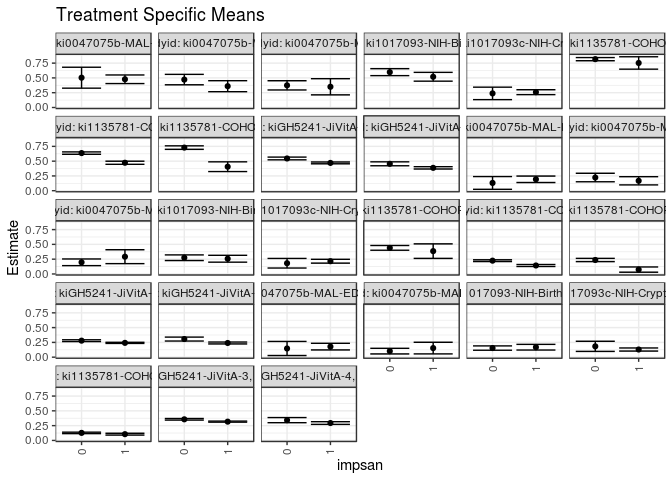

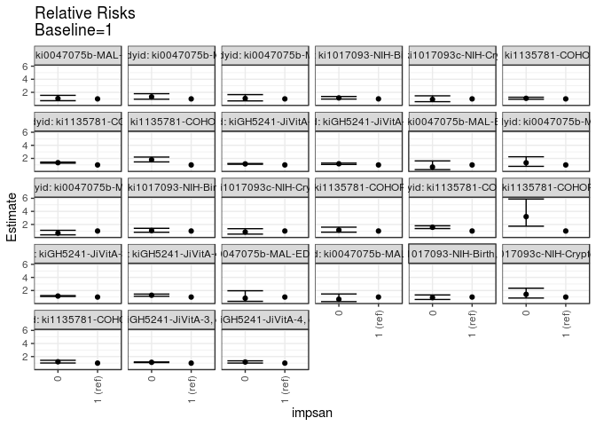

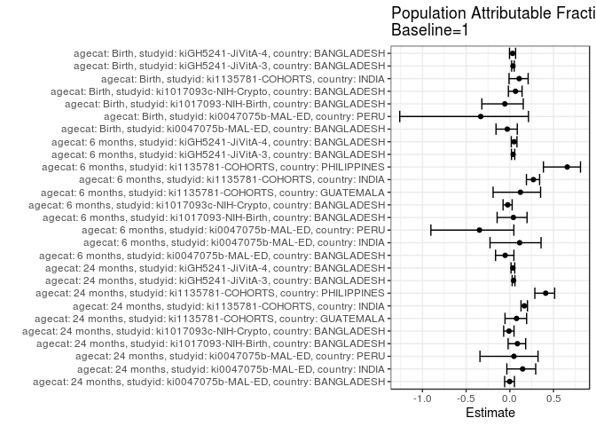

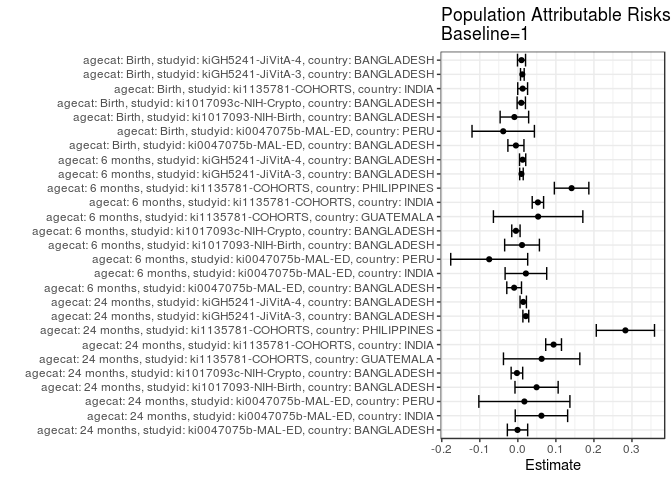

## Results Table

### Parameter: TSM

| agecat | studyid | country | intervention_level | baseline_level | estimate | ci_lower | ci_upper |
| --- | --- | --- | --- | --- | --- | --- | --- |
| Birth | ki0047075b-MAL-ED | BANGLADESH | 1 | NA | 0.1787709 | 0.1225078 | 0.2350341 |
| Birth | ki0047075b-MAL-ED | BANGLADESH | 0 | NA | 0.1470588 | 0.0277327 | 0.2663850 |
| Birth | ki0047075b-MAL-ED | PERU | 1 | NA | 0.1538462 | 0.0555445 | 0.2521478 |
| Birth | ki0047075b-MAL-ED | PERU | 0 | NA | 0.1025641 | 0.0548407 | 0.1502875 |
| Birth | ki1017093-NIH-Birth | BANGLADESH | 1 | NA | 0.1686354 | 0.1205511 | 0.2167196 |
| Birth | ki1017093-NIH-Birth | BANGLADESH | 0 | NA | 0.1541624 | 0.1176574 | 0.1906674 |
| Birth | ki1017093c-NIH-Crypto | BANGLADESH | 1 | NA | 0.1296614 | 0.1034251 | 0.1558976 |
| Birth | ki1017093c-NIH-Crypto | BANGLADESH | 0 | NA | 0.1832724 | 0.0975573 | 0.2689876 |
| Birth | ki1135781-COHORTS | INDIA | 1 | NA | 0.1056479 | 0.0903338 | 0.1209619 |
| Birth | ki1135781-COHORTS | INDIA | 0 | NA | 0.1272498 | 0.1151845 | 0.1393151 |
| Birth | kiGH5241-JiVitA-3 | BANGLADESH | 1 | NA | 0.3173116 | 0.3084055 | 0.3262178 |
| Birth | kiGH5241-JiVitA-3 | BANGLADESH | 0 | NA | 0.3566077 | 0.3431852 | 0.3700303 |
| Birth | kiGH5241-JiVitA-4 | BANGLADESH | 1 | NA | 0.2938863 | 0.2715050 | 0.3162676 |
| Birth | kiGH5241-JiVitA-4 | BANGLADESH | 0 | NA | 0.3425867 | 0.2991907 | 0.3859827 |
| 6 months | ki0047075b-MAL-ED | BANGLADESH | 1 | NA | 0.1930693 | 0.1385244 | 0.2476142 |
| 6 months | ki0047075b-MAL-ED | BANGLADESH | 0 | NA | 0.1315789 | 0.0238775 | 0.2392803 |
| 6 months | ki0047075b-MAL-ED | INDIA | 1 | NA | 0.1676420 | 0.0985168 | 0.2367673 |
| 6 months | ki0047075b-MAL-ED | INDIA | 0 | NA | 0.2232505 | 0.1514235 | 0.2950776 |
| 6 months | ki0047075b-MAL-ED | PERU | 1 | NA | 0.2920291 | 0.1747742 | 0.4092841 |
| 6 months | ki0047075b-MAL-ED | PERU | 0 | NA | 0.1972184 | 0.1408390 | 0.2535977 |
| 6 months | ki1017093-NIH-Birth | BANGLADESH | 1 | NA | 0.2571563 | 0.1989137 | 0.3153988 |
| 6 months | ki1017093-NIH-Birth | BANGLADESH | 0 | NA | 0.2743691 | 0.2269040 | 0.3218341 |
| 6 months | ki1017093c-NIH-Crypto | BANGLADESH | 1 | NA | 0.2152924 | 0.1827751 | 0.2478098 |
| 6 months | ki1017093c-NIH-Crypto | BANGLADESH | 0 | NA | 0.1813192 | 0.1003589 | 0.2622795 |
| 6 months | ki1135781-COHORTS | GUATEMALA | 1 | NA | 0.3858803 | 0.2629755 | 0.5087851 |
| 6 months | ki1135781-COHORTS | GUATEMALA | 0 | NA | 0.4407300 | 0.4006754 | 0.4807845 |
| 6 months | ki1135781-COHORTS | INDIA | 1 | NA | 0.1430134 | 0.1260060 | 0.1600208 |
| 6 months | ki1135781-COHORTS | INDIA | 0 | NA | 0.2246231 | 0.2098643 | 0.2393820 |
| 6 months | ki1135781-COHORTS | PHILIPPINES | 1 | NA | 0.0738316 | 0.0295128 | 0.1181504 |
| 6 months | ki1135781-COHORTS | PHILIPPINES | 0 | NA | 0.2359579 | 0.2087863 | 0.2631295 |
| 6 months | kiGH5241-JiVitA-3 | BANGLADESH | 1 | NA | 0.2419383 | 0.2325535 | 0.2513231 |
| 6 months | kiGH5241-JiVitA-3 | BANGLADESH | 0 | NA | 0.2793696 | 0.2640651 | 0.2946741 |
| 6 months | kiGH5241-JiVitA-4 | BANGLADESH | 1 | NA | 0.2398619 | 0.2238316 | 0.2558923 |
| 6 months | kiGH5241-JiVitA-4 | BANGLADESH | 0 | NA | 0.3066018 | 0.2733254 | 0.3398781 |
| 24 months | ki0047075b-MAL-ED | BANGLADESH | 1 | NA | 0.4772920 | 0.4047595 | 0.5498246 |
| 24 months | ki0047075b-MAL-ED | BANGLADESH | 0 | NA | 0.5036623 | 0.3266353 | 0.6806893 |
| 24 months | ki0047075b-MAL-ED | INDIA | 1 | NA | 0.3602012 | 0.2672099 | 0.4531924 |
| 24 months | ki0047075b-MAL-ED | INDIA | 0 | NA | 0.4717182 | 0.3836859 | 0.5597504 |
| 24 months | ki0047075b-MAL-ED | PERU | 1 | NA | 0.3501578 | 0.2135104 | 0.4868052 |
| 24 months | ki0047075b-MAL-ED | PERU | 0 | NA | 0.3743567 | 0.2962611 | 0.4524523 |
| 24 months | ki1017093-NIH-Birth | BANGLADESH | 1 | NA | 0.5195407 | 0.4452851 | 0.5937964 |
| 24 months | ki1017093-NIH-Birth | BANGLADESH | 0 | NA | 0.5975175 | 0.5386928 | 0.6563422 |
| 24 months | ki1017093c-NIH-Crypto | BANGLADESH | 1 | NA | 0.2589130 | 0.2175653 | 0.3002607 |
| 24 months | ki1017093c-NIH-Crypto | BANGLADESH | 0 | NA | 0.2381959 | 0.1330897 | 0.3433020 |
| 24 months | ki1135781-COHORTS | GUATEMALA | 1 | NA | 0.7526528 | 0.6477023 | 0.8576032 |
| 24 months | ki1135781-COHORTS | GUATEMALA | 0 | NA | 0.8170790 | 0.7904321 | 0.8437259 |
| 24 months | ki1135781-COHORTS | INDIA | 1 | NA | 0.4727885 | 0.4465635 | 0.4990135 |
| 24 months | ki1135781-COHORTS | INDIA | 0 | NA | 0.6364157 | 0.6164433 | 0.6563880 |
| 24 months | ki1135781-COHORTS | PHILIPPINES | 1 | NA | 0.4061331 | 0.3238824 | 0.4883837 |
| 24 months | ki1135781-COHORTS | PHILIPPINES | 0 | NA | 0.7293068 | 0.6997640 | 0.7588496 |
| 24 months | kiGH5241-JiVitA-3 | BANGLADESH | 1 | NA | 0.4702367 | 0.4550377 | 0.4854357 |
| 24 months | kiGH5241-JiVitA-3 | BANGLADESH | 0 | NA | 0.5450943 | 0.5221083 | 0.5680804 |
| 24 months | kiGH5241-JiVitA-4 | BANGLADESH | 1 | NA | 0.3867260 | 0.3670650 | 0.4063870 |
| 24 months | kiGH5241-JiVitA-4 | BANGLADESH | 0 | NA | 0.4550692 | 0.4220493 | 0.4880890 |

### Parameter: E(Y)

| agecat | studyid | country | intervention_level | baseline_level | estimate | ci_lower | ci_upper |
| --- | --- | --- | --- | --- | --- | --- | --- |
| Birth | ki0047075b-MAL-ED | BANGLADESH | NA | NA | 0.1737089 | 0.1227104 | 0.2247075 |
| Birth | ki0047075b-MAL-ED | PERU | NA | NA | 0.1153846 | 0.0718621 | 0.1589071 |
| Birth | ki1017093-NIH-Birth | BANGLADESH | NA | NA | 0.1595395 | 0.1304091 | 0.1886699 |
| Birth | ki1017093c-NIH-Crypto | BANGLADESH | NA | NA | 0.1386963 | 0.1134503 | 0.1639422 |
| Birth | ki1135781-COHORTS | INDIA | NA | NA | 0.1182998 | 0.1091394 | 0.1274602 |
| Birth | kiGH5241-JiVitA-3 | BANGLADESH | NA | NA | 0.3291427 | 0.3217640 | 0.3365214 |
| Birth | kiGH5241-JiVitA-4 | BANGLADESH | NA | NA | 0.3035461 | 0.2835868 | 0.3235054 |
| 6 months | ki0047075b-MAL-ED | BANGLADESH | NA | NA | 0.1833333 | 0.1342773 | 0.2323893 |
| 6 months | ki0047075b-MAL-ED | INDIA | NA | NA | 0.1888412 | 0.1384789 | 0.2392035 |
| 6 months | ki0047075b-MAL-ED | PERU | NA | NA | 0.2167300 | 0.1668401 | 0.2666199 |
| 6 months | ki1017093-NIH-Birth | BANGLADESH | NA | NA | 0.2681564 | 0.2306532 | 0.3056597 |
| 6 months | ki1017093c-NIH-Crypto | BANGLADESH | NA | NA | 0.2102273 | 0.1801065 | 0.2403480 |
| 6 months | ki1135781-COHORTS | GUATEMALA | NA | NA | 0.4392097 | 0.4012606 | 0.4771588 |
| 6 months | ki1135781-COHORTS | INDIA | NA | NA | 0.1957353 | 0.1847045 | 0.2067660 |
| 6 months | ki1135781-COHORTS | PHILIPPINES | NA | NA | 0.2151431 | 0.1906585 | 0.2396277 |
| 6 months | kiGH5241-JiVitA-3 | BANGLADESH | NA | NA | 0.2514286 | 0.2432891 | 0.2595681 |
| 6 months | kiGH5241-JiVitA-4 | BANGLADESH | NA | NA | 0.2524352 | 0.2383740 | 0.2664965 |
| 24 months | ki0047075b-MAL-ED | BANGLADESH | NA | NA | 0.4764151 | 0.4090254 | 0.5438047 |
| 24 months | ki0047075b-MAL-ED | INDIA | NA | NA | 0.4222222 | 0.3575415 | 0.4869030 |
| 24 months | ki0047075b-MAL-ED | PERU | NA | NA | 0.3673469 | 0.2996839 | 0.4350100 |
| 24 months | ki1017093-NIH-Birth | BANGLADESH | NA | NA | 0.5687646 | 0.5218455 | 0.6156837 |
| 24 months | ki1017093c-NIH-Crypto | BANGLADESH | NA | NA | 0.2564612 | 0.2182616 | 0.2946608 |
| 24 months | ki1135781-COHORTS | GUATEMALA | NA | NA | 0.8152296 | 0.7897600 | 0.8406991 |
| 24 months | ki1135781-COHORTS | INDIA | NA | NA | 0.5667822 | 0.5509225 | 0.5826418 |
| 24 months | ki1135781-COHORTS | PHILIPPINES | NA | NA | 0.6888889 | 0.6600365 | 0.7177413 |
| 24 months | kiGH5241-JiVitA-3 | BANGLADESH | NA | NA | 0.4911853 | 0.4780778 | 0.5042929 |
| 24 months | kiGH5241-JiVitA-4 | BANGLADESH | NA | NA | 0.4008848 | 0.3839144 | 0.4178552 |

### Parameter: RR

| agecat | studyid | country | intervention_level | baseline_level | estimate | ci_lower | ci_upper |
| --- | --- | --- | --- | --- | --- | --- | --- |
| Birth | ki0047075b-MAL-ED | BANGLADESH | 1 | 1 | 1.0000000 | 1.0000000 | 1.000000 |
| Birth | ki0047075b-MAL-ED | BANGLADESH | 0 | 1 | 0.8226103 | 0.3445252 | 1.964117 |
| Birth | ki0047075b-MAL-ED | PERU | 1 | 1 | 1.0000000 | 1.0000000 | 1.000000 |
| Birth | ki0047075b-MAL-ED | PERU | 0 | 1 | 0.6666667 | 0.3024334 | 1.469562 |
| Birth | ki1017093-NIH-Birth | BANGLADESH | 1 | 1 | 1.0000000 | 1.0000000 | 1.000000 |
| Birth | ki1017093-NIH-Birth | BANGLADESH | 0 | 1 | 0.9141760 | 0.6321415 | 1.322042 |
| Birth | ki1017093c-NIH-Crypto | BANGLADESH | 1 | 1 | 1.0000000 | 1.0000000 | 1.000000 |
| Birth | ki1017093c-NIH-Crypto | BANGLADESH | 0 | 1 | 1.4134699 | 0.8486865 | 2.354105 |
| Birth | ki1135781-COHORTS | INDIA | 1 | 1 | 1.0000000 | 1.0000000 | 1.000000 |
| Birth | ki1135781-COHORTS | INDIA | 0 | 1 | 1.2044711 | 1.0131364 | 1.431940 |
| Birth | kiGH5241-JiVitA-3 | BANGLADESH | 1 | 1 | 1.0000000 | 1.0000000 | 1.000000 |
| Birth | kiGH5241-JiVitA-3 | BANGLADESH | 0 | 1 | 1.1238407 | 1.0756794 | 1.174158 |
| Birth | kiGH5241-JiVitA-4 | BANGLADESH | 1 | 1 | 1.0000000 | 1.0000000 | 1.000000 |
| Birth | kiGH5241-JiVitA-4 | BANGLADESH | 0 | 1 | 1.1657116 | 1.0073168 | 1.349013 |
| 6 months | ki0047075b-MAL-ED | BANGLADESH | 1 | 1 | 1.0000000 | 1.0000000 | 1.000000 |
| 6 months | ki0047075b-MAL-ED | BANGLADESH | 0 | 1 | 0.6815115 | 0.2866894 | 1.620074 |
| 6 months | ki0047075b-MAL-ED | INDIA | 1 | 1 | 1.0000000 | 1.0000000 | 1.000000 |
| 6 months | ki0047075b-MAL-ED | INDIA | 0 | 1 | 1.3317098 | 0.7873197 | 2.252517 |
| 6 months | ki0047075b-MAL-ED | PERU | 1 | 1 | 1.0000000 | 1.0000000 | 1.000000 |
| 6 months | ki0047075b-MAL-ED | PERU | 0 | 1 | 0.6753381 | 0.4127779 | 1.104908 |
| 6 months | ki1017093-NIH-Birth | BANGLADESH | 1 | 1 | 1.0000000 | 1.0000000 | 1.000000 |
| 6 months | ki1017093-NIH-Birth | BANGLADESH | 0 | 1 | 1.0669351 | 0.8072731 | 1.410118 |
| 6 months | ki1017093c-NIH-Crypto | BANGLADESH | 1 | 1 | 1.0000000 | 1.0000000 | 1.000000 |
| 6 months | ki1017093c-NIH-Crypto | BANGLADESH | 0 | 1 | 0.8421997 | 0.5260464 | 1.348361 |
| 6 months | ki1135781-COHORTS | GUATEMALA | 1 | 1 | 1.0000000 | 1.0000000 | 1.000000 |
| 6 months | ki1135781-COHORTS | GUATEMALA | 0 | 1 | 1.1421417 | 0.8219568 | 1.587051 |
| 6 months | ki1135781-COHORTS | INDIA | 1 | 1 | 1.0000000 | 1.0000000 | 1.000000 |
| 6 months | ki1135781-COHORTS | INDIA | 0 | 1 | 1.5706439 | 1.3721231 | 1.797887 |
| 6 months | ki1135781-COHORTS | PHILIPPINES | 1 | 1 | 1.0000000 | 1.0000000 | 1.000000 |
| 6 months | ki1135781-COHORTS | PHILIPPINES | 0 | 1 | 3.1958936 | 1.7340693 | 5.890039 |
| 6 months | kiGH5241-JiVitA-3 | BANGLADESH | 1 | 1 | 1.0000000 | 1.0000000 | 1.000000 |
| 6 months | kiGH5241-JiVitA-3 | BANGLADESH | 0 | 1 | 1.1547140 | 1.0849274 | 1.228990 |
| 6 months | kiGH5241-JiVitA-4 | BANGLADESH | 1 | 1 | 1.0000000 | 1.0000000 | 1.000000 |
| 6 months | kiGH5241-JiVitA-4 | BANGLADESH | 0 | 1 | 1.2782427 | 1.1220536 | 1.456173 |
| 24 months | ki0047075b-MAL-ED | BANGLADESH | 1 | 1 | 1.0000000 | 1.0000000 | 1.000000 |
| 24 months | ki0047075b-MAL-ED | BANGLADESH | 0 | 1 | 1.0552498 | 0.7227043 | 1.540813 |
| 24 months | ki0047075b-MAL-ED | INDIA | 1 | 1 | 1.0000000 | 1.0000000 | 1.000000 |
| 24 months | ki0047075b-MAL-ED | INDIA | 0 | 1 | 1.3095965 | 0.9552931 | 1.795306 |
| 24 months | ki0047075b-MAL-ED | PERU | 1 | 1 | 1.0000000 | 1.0000000 | 1.000000 |
| 24 months | ki0047075b-MAL-ED | PERU | 0 | 1 | 1.0691086 | 0.6907087 | 1.654812 |
| 24 months | ki1017093-NIH-Birth | BANGLADESH | 1 | 1 | 1.0000000 | 1.0000000 | 1.000000 |
| 24 months | ki1017093-NIH-Birth | BANGLADESH | 0 | 1 | 1.1500879 | 0.9691525 | 1.364803 |
| 24 months | ki1017093c-NIH-Crypto | BANGLADESH | 1 | 1 | 1.0000000 | 1.0000000 | 1.000000 |
| 24 months | ki1017093c-NIH-Crypto | BANGLADESH | 0 | 1 | 0.9199842 | 0.5754561 | 1.470783 |
| 24 months | ki1135781-COHORTS | GUATEMALA | 1 | 1 | 1.0000000 | 1.0000000 | 1.000000 |
| 24 months | ki1135781-COHORTS | GUATEMALA | 0 | 1 | 1.0855989 | 0.9412375 | 1.252101 |
| 24 months | ki1135781-COHORTS | INDIA | 1 | 1 | 1.0000000 | 1.0000000 | 1.000000 |
| 24 months | ki1135781-COHORTS | INDIA | 0 | 1 | 1.3460895 | 1.2645680 | 1.432866 |
| 24 months | ki1135781-COHORTS | PHILIPPINES | 1 | 1 | 1.0000000 | 1.0000000 | 1.000000 |
| 24 months | ki1135781-COHORTS | PHILIPPINES | 0 | 1 | 1.7957335 | 1.4626596 | 2.204654 |
| 24 months | kiGH5241-JiVitA-3 | BANGLADESH | 1 | 1 | 1.0000000 | 1.0000000 | 1.000000 |
| 24 months | kiGH5241-JiVitA-3 | BANGLADESH | 0 | 1 | 1.1591914 | 1.1028960 | 1.218360 |
| 24 months | kiGH5241-JiVitA-4 | BANGLADESH | 1 | 1 | 1.0000000 | 1.0000000 | 1.000000 |
| 24 months | kiGH5241-JiVitA-4 | BANGLADESH | 0 | 1 | 1.1767225 | 1.0774945 | 1.285089 |

### Parameter: PAR

| agecat | studyid | country | intervention_level | baseline_level | estimate | ci_lower | ci_upper |
| --- | --- | --- | --- | --- | --- | --- | --- |
| Birth | ki0047075b-MAL-ED | BANGLADESH | 1 | NA | -0.0050620 | -0.0261785 | 0.0160544 |
| Birth | ki0047075b-MAL-ED | PERU | 1 | NA | -0.0384615 | -0.1204726 | 0.0435496 |
| Birth | ki1017093-NIH-Birth | BANGLADESH | 1 | NA | -0.0090959 | -0.0465783 | 0.0283865 |
| Birth | ki1017093c-NIH-Crypto | BANGLADESH | 1 | NA | 0.0090349 | -0.0019078 | 0.0199776 |
| Birth | ki1135781-COHORTS | INDIA | 1 | NA | 0.0126520 | -0.0002866 | 0.0255905 |
| Birth | kiGH5241-JiVitA-3 | BANGLADESH | 1 | NA | 0.0118311 | 0.0069768 | 0.0166854 |
| Birth | kiGH5241-JiVitA-4 | BANGLADESH | 1 | NA | 0.0096598 | -0.0009151 | 0.0202347 |
| 6 months | ki0047075b-MAL-ED | BANGLADESH | 1 | NA | -0.0097360 | -0.0290616 | 0.0095896 |
| 6 months | ki0047075b-MAL-ED | INDIA | 1 | NA | 0.0211992 | -0.0334839 | 0.0758823 |
| 6 months | ki0047075b-MAL-ED | PERU | 1 | NA | -0.0752991 | -0.1764614 | 0.0258632 |
| 6 months | ki1017093-NIH-Birth | BANGLADESH | 1 | NA | 0.0110002 | -0.0346981 | 0.0566984 |
| 6 months | ki1017093c-NIH-Crypto | BANGLADESH | 1 | NA | -0.0050651 | -0.0160079 | 0.0058776 |
| 6 months | ki1135781-COHORTS | GUATEMALA | 1 | NA | 0.0533295 | -0.0642151 | 0.1708740 |
| 6 months | ki1135781-COHORTS | INDIA | 1 | NA | 0.0527219 | 0.0377506 | 0.0676931 |
| 6 months | ki1135781-COHORTS | PHILIPPINES | 1 | NA | 0.1413115 | 0.0959776 | 0.1866455 |
| 6 months | kiGH5241-JiVitA-3 | BANGLADESH | 1 | NA | 0.0094902 | 0.0048442 | 0.0141363 |
| 6 months | kiGH5241-JiVitA-4 | BANGLADESH | 1 | NA | 0.0125733 | 0.0044092 | 0.0207374 |
| 24 months | ki0047075b-MAL-ED | BANGLADESH | 1 | NA | -0.0008769 | -0.0275781 | 0.0258243 |
| 24 months | ki0047075b-MAL-ED | INDIA | 1 | NA | 0.0620211 | -0.0068643 | 0.1309064 |
| 24 months | ki0047075b-MAL-ED | PERU | 1 | NA | 0.0171892 | -0.1024984 | 0.1368767 |
| 24 months | ki1017093-NIH-Birth | BANGLADESH | 1 | NA | 0.0492238 | -0.0075233 | 0.1059709 |
| 24 months | ki1017093c-NIH-Crypto | BANGLADESH | 1 | NA | -0.0024518 | -0.0176444 | 0.0127409 |
| 24 months | ki1135781-COHORTS | GUATEMALA | 1 | NA | 0.0625768 | -0.0378094 | 0.1629630 |
| 24 months | ki1135781-COHORTS | INDIA | 1 | NA | 0.0939937 | 0.0732554 | 0.1147320 |
| 24 months | ki1135781-COHORTS | PHILIPPINES | 1 | NA | 0.2827558 | 0.2062352 | 0.3592765 |
| 24 months | kiGH5241-JiVitA-3 | BANGLADESH | 1 | NA | 0.0209486 | 0.0132548 | 0.0286425 |
| 24 months | kiGH5241-JiVitA-4 | BANGLADESH | 1 | NA | 0.0141588 | 0.0057723 | 0.0225453 |

### Parameter: PAF

| agecat | studyid | country | intervention_level | baseline_level | estimate | ci_lower | ci_upper |
| --- | --- | --- | --- | --- | --- | --- | --- |
| Birth | ki0047075b-MAL-ED | BANGLADESH | 1 | NA | -0.0291409 | -0.1579815 | 0.0853646 |
| Birth | ki0047075b-MAL-ED | PERU | 1 | NA | -0.3333333 | -1.2598233 | 0.2133112 |
| Birth | ki1017093-NIH-Birth | BANGLADESH | 1 | NA | -0.0570134 | -0.3200509 | 0.1536105 |
| Birth | ki1017093c-NIH-Crypto | BANGLADESH | 1 | NA | 0.0651415 | -0.0165417 | 0.1402612 |
| Birth | ki1135781-COHORTS | INDIA | 1 | NA | 0.1069483 | -0.0090923 | 0.2096447 |
| Birth | kiGH5241-JiVitA-3 | BANGLADESH | 1 | NA | 0.0359451 | 0.0210461 | 0.0506173 |
| Birth | kiGH5241-JiVitA-4 | BANGLADESH | 1 | NA | 0.0318230 | -0.0036667 | 0.0660579 |
| 6 months | ki0047075b-MAL-ED | BANGLADESH | 1 | NA | -0.0531053 | -0.1634147 | 0.0467451 |
| 6 months | ki0047075b-MAL-ED | INDIA | 1 | NA | 0.1122592 | -0.2266210 | 0.3575166 |
| 6 months | ki0047075b-MAL-ED | PERU | 1 | NA | -0.3474326 | -0.9034418 | 0.0461623 |
| 6 months | ki1017093-NIH-Birth | BANGLADESH | 1 | NA | 0.0410214 | -0.1453853 | 0.1970912 |
| 6 months | ki1017093c-NIH-Crypto | BANGLADESH | 1 | NA | -0.0240937 | -0.0774441 | 0.0266151 |
| 6 months | ki1135781-COHORTS | GUATEMALA | 1 | NA | 0.1214214 | -0.1914795 | 0.3521497 |
| 6 months | ki1135781-COHORTS | INDIA | 1 | NA | 0.2693529 | 0.1899406 | 0.3409801 |
| 6 months | ki1135781-COHORTS | PHILIPPINES | 1 | NA | 0.6568257 | 0.3845119 | 0.8086582 |
| 6 months | kiGH5241-JiVitA-3 | BANGLADESH | 1 | NA | 0.0377453 | 0.0190431 | 0.0560909 |
| 6 months | kiGH5241-JiVitA-4 | BANGLADESH | 1 | NA | 0.0498080 | 0.0168794 | 0.0816338 |
| 24 months | ki0047075b-MAL-ED | BANGLADESH | 1 | NA | -0.0018407 | -0.0594843 | 0.0526666 |
| 24 months | ki0047075b-MAL-ED | INDIA | 1 | NA | 0.1468920 | -0.0339184 | 0.2960825 |
| 24 months | ki0047075b-MAL-ED | PERU | 1 | NA | 0.0467927 | -0.3416206 | 0.3227563 |
| 24 months | ki1017093-NIH-Birth | BANGLADESH | 1 | NA | 0.0865452 | -0.0193024 | 0.1814012 |
| 24 months | ki1017093c-NIH-Crypto | BANGLADESH | 1 | NA | -0.0095600 | -0.0705647 | 0.0479685 |
| 24 months | ki1135781-COHORTS | GUATEMALA | 1 | NA | 0.0767597 | -0.0551496 | 0.1921784 |
| 24 months | ki1135781-COHORTS | INDIA | 1 | NA | 0.1658374 | 0.1280823 | 0.2019576 |
| 24 months | ki1135781-COHORTS | PHILIPPINES | 1 | NA | 0.4104520 | 0.2862622 | 0.5130329 |
| 24 months | kiGH5241-JiVitA-3 | BANGLADESH | 1 | NA | 0.0426492 | 0.0268145 | 0.0582262 |
| 24 months | kiGH5241-JiVitA-4 | BANGLADESH | 1 | NA | 0.0353188 | 0.0139653 | 0.0562100 |